# Probability with vanilla R

Dylan Chua

November 2024

# 1 Simulation of the probability that athletes took drugs given a positive test result

In this exercise you will simulate the conditional probability that an athlete took drugs, given he/she failed a drug test.

Scenario: Suppose you have a population of 100 athletes. It is known that 10% of athletes take drugs. There is a test that will correctly identify 80% of drug users and also incorrectly identify 20% of clean athletes as drug users.

Simulate this situation: Each athlete in population of size 100 has probability 0.1 of being a drug taker. For each simulated athlete, generate a random integer 1-10 - if this is 1 the simulated athlete takes drugs, if this is 2-10 does not take drugs. 80% of the population is correctly identified by the test - for each simulated athlete, generate a second random integer 1-10 - if this is 1 or 2 the simulated athlete’s test is incorrect, otherwise correct.

Athletes who fail the test include drug takers correctly identified as cheats and clean athletes incorrectly identified as cheats. So a simulated athlete is deemed to have failed if his/her 1st random integer is 1 and 2nd random integer is 3-10 OR 1st integer 2-10 and 2nd integer 1-2.

You are now in a position to calculate the first simulated conditional probability of drug taking among the athletes who failed the test.

```r
simulation <- function(
    n = 100,
    p_drug = 0.1,
    p_true_pos = 0.8,
    p_false_pos = 0.2,
    two_tests = FALSE) {
  # population of athletes
  drug <- runif(n) < p_drug
  # test results
  test <- runif(n)

  # simulate drug test
  # if drug taker and correctly identified or clean and incorrectly identified
  if (two_tests) {
    second_test <- runif(n)
    result <- (drug & test <= p_true_pos & second_test <= p_true_pos) |
      (!drug & test <= p_false_pos & second_test <= p_false_pos)
  } else {
    result <- (drug & test <= p_true_pos) | (!drug & test <= p_false_pos)
  }

  # calculate conditional probability of drug taking given failed test
  p_drug_fail <- sum(drug & result) / sum(result)

  return(p_drug_fail)
}

simulation()
```

```
## [1] 0.28125
```

```r
plot_density <- function(simulations, main = "P(takes drugs | failed test)") {
  hist(simulations,
    main = main,
    freq = FALSE,
    xlab = "Probability",
    col = "skyblue",
    border = "white",
    xlim = c(0, 1)
  )
  lines(density(simulations),
    lwd = 2,
    col = "red"
  )
}
```

### 1. Repeat this simulation many times (for example, 1000 times). Plot (histogram or density) the resulting simulated probabilities. What would you consider to be an unusual result?

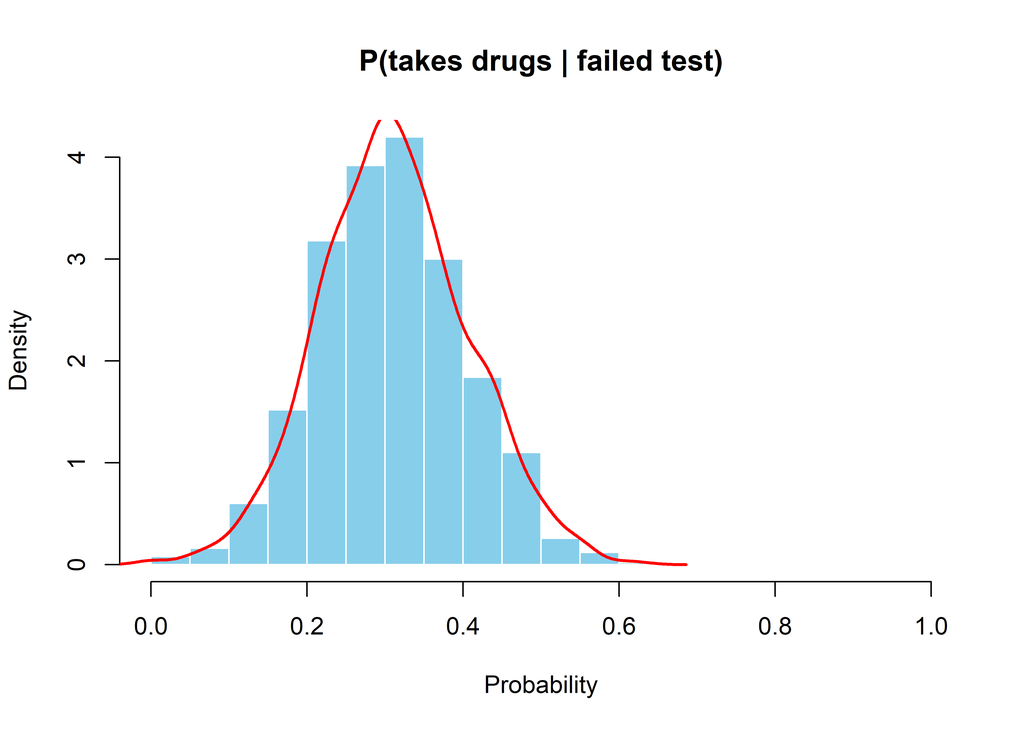

```r
# repeat simulation 1000 times
simulations <- replicate(1000, simulation())

# plot histogram of simulated probabilities
plot_density(simulations)
```

### 2. Try changing the assumptions/ parameters of the model - for instance, change the rate of drug taking in the population of athletes, the proportion of drug takers correctly identified by the test, the proportion of clean athletes incorrectly identified (in this example these last two proportions are equal, but this would usually not be the case).

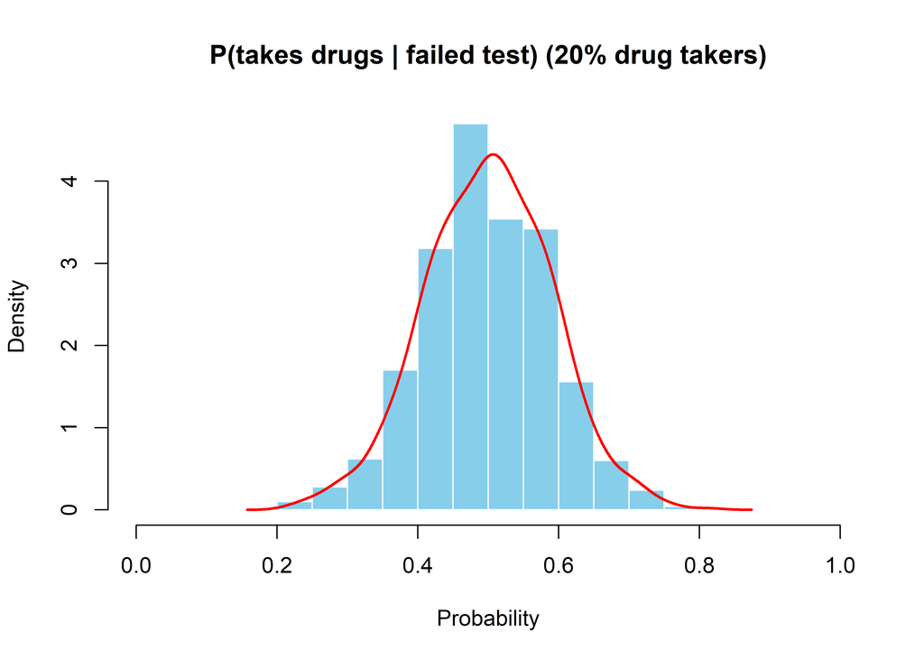

```r
# probability of drug taking in the population of athletes increased to 20%
p_drug_simulations <- replicate(1000, simulation(p_drug = 0.2))

# plot histogram of simulated probabilities
plot_density(p_drug_simulations,
  main = "P(takes drugs | failed test) (20% drug takers)"
)
```

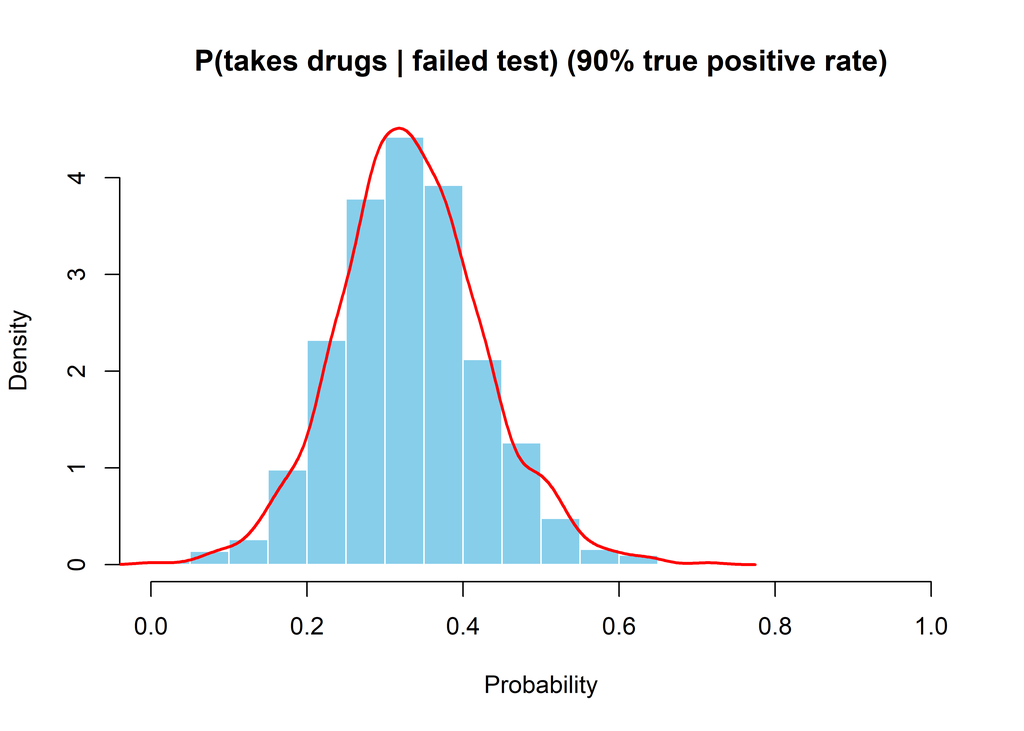

```r
# proportion of drug takers correctly identified by the test increased to 90%
p_true_pos_simulations <- replicate(1000, simulation(p_true_pos = 0.9))

# plot histogram of simulated probabilities
plot_density(p_true_pos_simulations,
  main = "P(takes drugs | failed test) (90% true positive rate)"
)
```

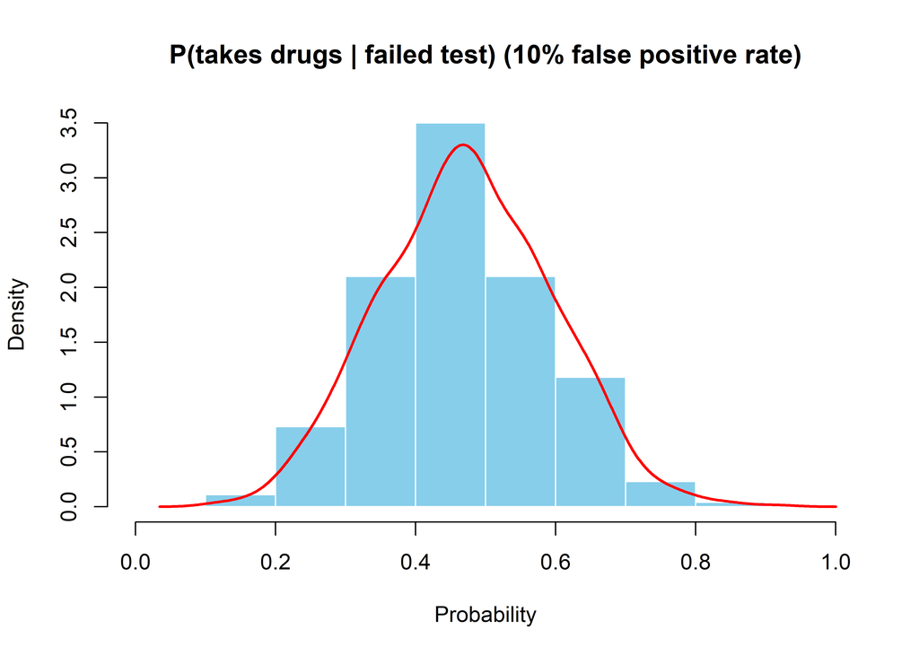

```r
# false positive rate increased to 10%
p_false_pos_simulations <- replicate(1000, simulation(p_false_pos = 0.1))

# plot histogram of simulated probabilities
plot_density(p_false_pos_simulations,
  main = "P(takes drugs | failed test) (10% false positive rate)"
)
```

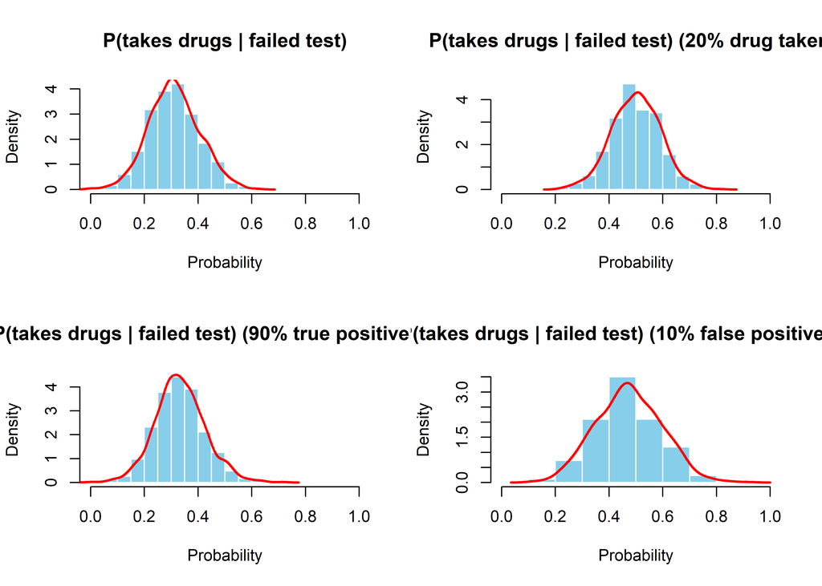

```r
# compare the simulations
par(mfrow = c(2, 2))
plot_density(simulations, main = "P(takes drugs | failed test)")
plot_density(p_drug_simulations,
  main = "P(takes drugs | failed test) (20% drug takers)"
)
plot_density(p_true_pos_simulations,
  main = "P(takes drugs | failed test) (90% true positive rate)"
)
plot_density(p_false_pos_simulations,
  main = "P(takes drugs | failed test) (10% false positive rate)"
)
```

### 3. Now simulate the situation where the athlete is only deemed to have failed if he/she has failed two tests, where the tests are conditionally independent given the athlete’s drug-taking status.

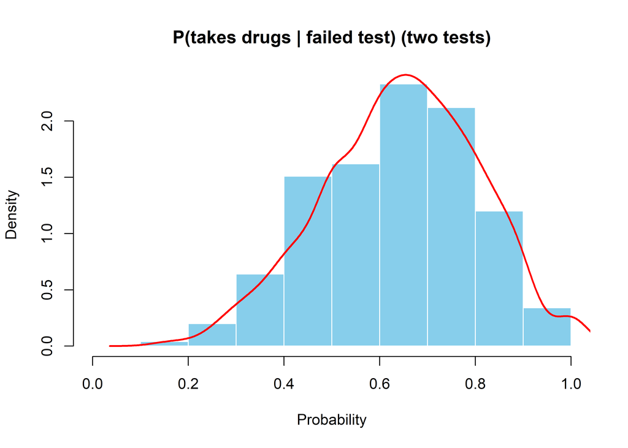

```r
# repeat simulation 1000 times
simulations_two_tests <- replicate(1000, simulation(two_tests = TRUE))

# plot histogram of simulated probabilities
par(mfrow = c(1, 1))
plot_density(simulations_two_tests,
  main = "P(takes drugs | failed test) (two tests)"
)
```

### 4. Can you suggest ways to improve the simulation (e.g. write code efficiently)?

### 5. Use Bayes’ Theorem to calculate the conditional probability of drug taking given failing (a) one test (b) two tests that are conditionally independent given drug-taking status. (Use the probabilites as specified in the original scenario.) Does this agree with your simulation?

```r
# Bayes' Theorem
# P(takes drugs | failed test) = P(takes drugs and failed test) / P(failed test)

p_drug <- 0.1
p_true_pos <- 0.8
p_false_pos <- 0.2

print(paste(
  "P(takes drugs | failed test): ",
  p_drug * p_true_pos / (p_drug * p_true_pos + (1 - p_drug) * p_false_pos)
))
```

```
## [1] "P(takes drugs | failed test):  0.307692307692308"
```

# 2 Probability Distributions

Initially choose two distributions (one discrete and one continuous).

Selected: Poisson and Gamma distributions.

### 1. Plot the p.m.f. or p.d.f. and c.d.f. for a suitable choice of parameters for each distribution. You decide the range of values and parameter(s) for each distribution.

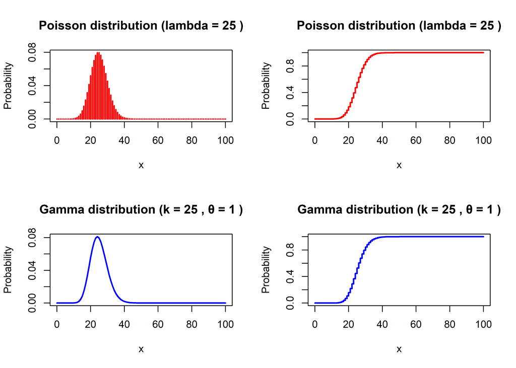

```r
points <- seq(0, 100, by = 1)
par(mfrow = c(2, 2))

# Poisson distribution
lambda <- 25
poisson_pmf <- dpois(points, lambda = lambda)
plot(points, poisson_pmf,
  type = "h",
  lwd = 2,
  col = "red",
  xlab = "x",
  ylab = "Probability",
  main = paste("Poisson distribution (lambda =", lambda, ")")
)

poisson_cdf <- ppois(points, lambda = lambda)
plot(points, poisson_cdf,
  type = "s",
  lwd = 2,
  col = "red",
  xlab = "x",
  ylab = "Probability",
  main = paste("Poisson distribution (lambda =", lambda, ")")
)

# Gamma distribution
shape <- 25
scale <- 1
gamma_pdf <- dgamma(points, shape = shape, scale = scale)
plot(points, gamma_pdf,
  type = "l",
  lwd = 2,
  col = "blue",
  xlab = "x",
  ylab = "Probability",
  main = paste("Gamma distribution (k =", shape, ", θ =", scale, ")")
)

gamma_cdf <- pgamma(points, shape = shape, scale = scale)
plot(points, gamma_cdf,
  type = "s",
  lwd = 2,
  col = "blue",
  xlab = "x",
  ylab = "Probability",
  main = paste("Gamma distribution (k =", shape, ", θ =", scale, ")")
)
```

### 2. Generate n = 100 random numbers from each distribution.

```r
n <- 100

generate_distributions <- function(n, lambda, shape, scale) {
  # Poisson distribution
  poisson_rvs <- rpois(n, lambda = lambda)

  # Gamma distribution
  gamma_rvs <- rgamma(n, shape = shape, scale = scale)

  return(list(poisson_rvs = poisson_rvs, gamma_rvs = gamma_rvs))
}

distributions <- generate_distributions(n, lambda, shape, scale)
poisson_rvs <- distributions$poisson_rvs
gamma_rvs <- distributions$gamma_rvs
```

1. Plot histograms of the relative frequency distribution of your random sample using appropriate bin widths.
2. Overlay the true probability density function. Do they match?

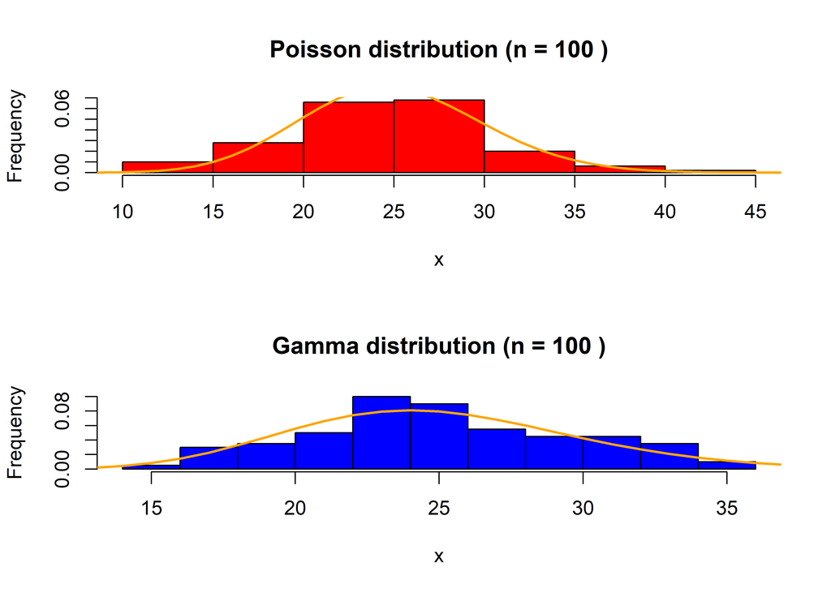

```r
plot_distributions <- function(distributions, points, poisson_pmf, gamma_pdf) {
  n <- length(distributions$poisson_rvs)
  poisson_rvs <- distributions$poisson_rvs
  gamma_rvs <- distributions$gamma_rvs

  par(mfrow = c(2, 1))

  hist(poisson_rvs,
    freq = FALSE,
    col = "red",
    xlab = "x",
    ylab = "Frequency",
    main = paste("Poisson distribution (n =", n, ")")
  )
  # overlay true probability density function
  lines(points, poisson_pmf,
    lwd = 2,
    col = "orange"
  )

  hist(gamma_rvs,
    freq = FALSE,
    col = "blue",
    xlab = "x",
    ylab = "Frequency",
    main = paste("Gamma distribution (n =", n, ")")
  )
  # overlay true probability density function
  lines(points, gamma_pdf,
    lwd = 2,
    col = "orange"
  )
}

plot_distributions(distributions, points, poisson_pmf, gamma_pdf)
```

3. Analytically calculate the theoretical mean and variance given your choice of parameters.

```r
# Poisson distribution
poisson_mean <- lambda
poisson_variance <- lambda
print(paste("Poisson distribution: mean =", poisson_mean))
```

```
## [1] "Poisson distribution: mean = 25"
```

```r
print(paste("Poisson distribution: variance =", poisson_variance))
```

```
## [1] "Poisson distribution: variance = 25"
```

```r
# Gamma distribution
gamma_mean <- shape * scale
gamma_variance <- shape * scale^2
print(paste("Gamma distribution: mean =", gamma_mean))
```

```
## [1] "Gamma distribution: mean = 25"
```

```r
print(paste("Gamma distribution: variance =", gamma_variance))
```

```
## [1] "Gamma distribution: variance = 25"
```

4. Calculate the sample mean (mean) and variance (var) for your random sample. Do they match the theoretical quantities?

```r
# Poisson distribution
poisson_mean_sample <- mean(poisson_rvs)
poisson_variance_sample <- var(poisson_rvs)
print(paste("Poisson distribution: sample mean =", poisson_mean_sample))
```

```
## [1] "Poisson distribution: sample mean = 25.14"
```

```r
print(paste("Poisson distribution: sample variance =", poisson_variance_sample))
```

```
## [1] "Poisson distribution: sample variance = 27.5559595959596"
```

```r
# Gamma distribution
gamma_mean_sample <- mean(gamma_rvs)
gamma_variance_sample <- var(gamma_rvs)
print(paste("Gamma distribution: sample mean =", gamma_mean_sample))
```

```
## [1] "Gamma distribution: sample mean = 25.2119238442573"
```

```r
print(paste("Gamma distribution: sample variance =", gamma_variance_sample))
```

```
## [1] "Gamma distribution: sample variance = 21.3199263974766"
```

5. Repeat (a-d) using n = 200, 500, 1000. What happens as the sample size increases?

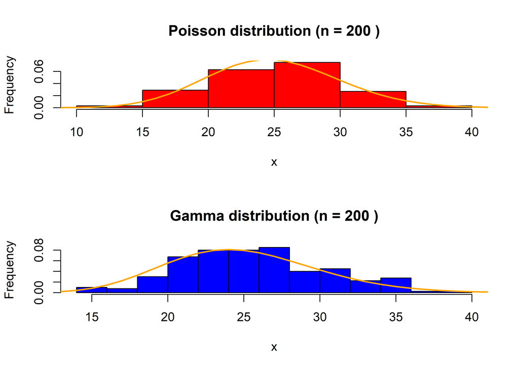

```
## [1] "Poisson distribution (n = 200 ): sample mean = 25.465"
## [1] "Poisson distribution (n = 200 ): sample variance = 22.7726381909548"
## [1] "Gamma distribution (n = 200 ): sample mean = 25.6569577244637"
## [1] "Gamma distribution (n = 200 ): sample variance = 22.5744235852123"
```

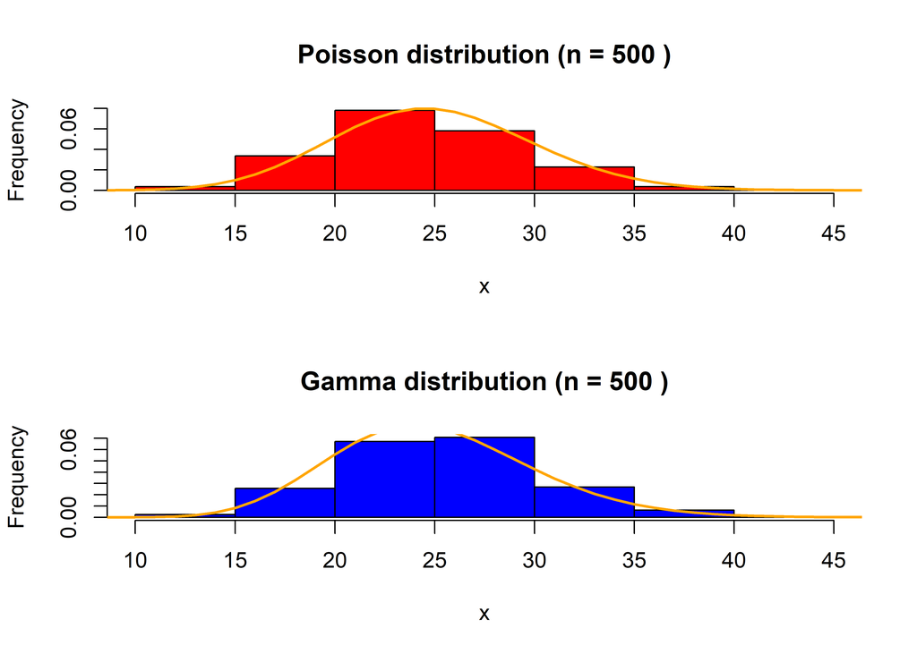

```
## [1] "Poisson distribution (n = 500 ): sample mean = 24.868"
## [1] "Poisson distribution (n = 500 ): sample variance = 23.4735230460922"
## [1] "Gamma distribution (n = 500 ): sample mean = 25.3438195478796"
## [1] "Gamma distribution (n = 500 ): sample variance = 24.5253987136916"
```

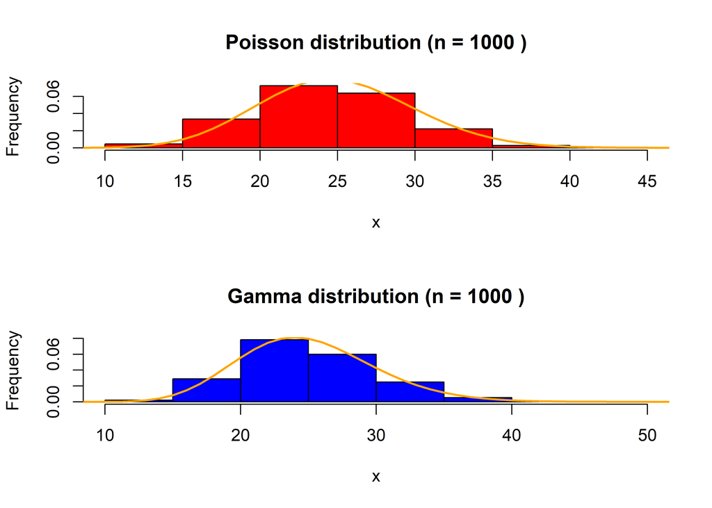

```
## [1] "Poisson distribution (n = 1000 ): sample mean = 24.88"
## [1] "Poisson distribution (n = 1000 ): sample variance = 24.2178178178178"
## [1] "Gamma distribution (n = 1000 ): sample mean = 24.8078755616693"
## [1] "Gamma distribution (n = 1000 ): sample variance = 24.3592439658642"
```

```r
n_values <- c(200, 500, 1000)

for (n in n_values) {
  distributions <- generate_distributions(n, lambda, shape, scale)
  poisson_rvs <- distributions$poisson_rvs
  gamma_rvs <- distributions$gamma_rvs

  plot_distributions(distributions, points, poisson_pmf, gamma_pdf)

  print(paste("Poisson distribution (n =", n, "): sample mean =", mean(poisson_rvs)))
  print(paste("Poisson distribution (n =", n, "): sample variance =", var(poisson_rvs)))

  print(paste("Gamma distribution (n =", n, "): sample mean =", mean(gamma_rvs)))
  print(paste("Gamma distribution (n =", n, "): sample variance =", var(gamma_rvs)))
}
```